# **Crude Oil to Cancer**

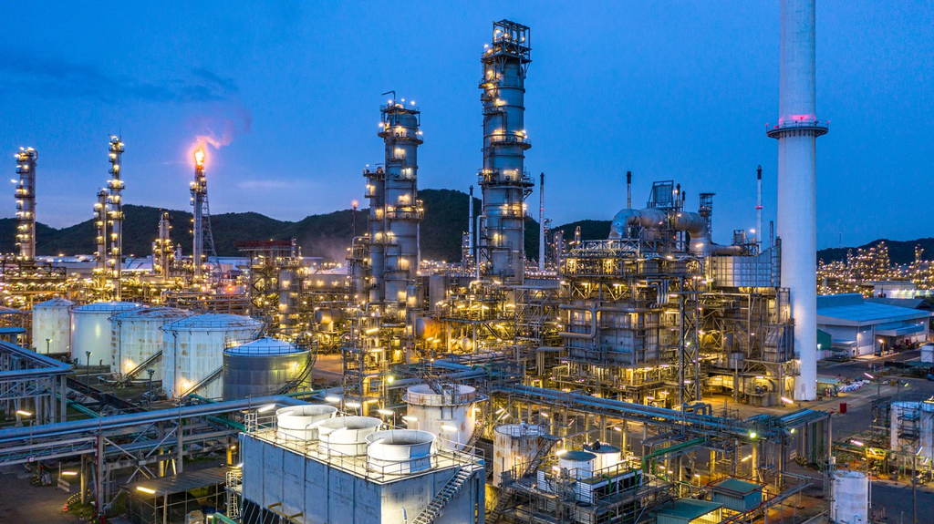

# **Team Members: Emily Aymond & Meryl Larue**

Webpage: https://emilyaymond.github.io/

# **1. Summary**

**Objective**

This project will investigate the relationship between proximity to petrochemical plants, racial and ethnic minority status, and cancer rates within an area. We will examine Leukemia cancer, which is known to be caused by petrochemical plants.

We will examine cancer rates in relation to social vulnerability index in the eleven parishes of Cancer Alley in Louisiana in comparison with the rest of Louisiana and Vermont, a state that does not have petrochemical plants.

Research Question: What is the relationship between proximity to petrochemical plants, racial and ethnic minority status, and cancer rates within Cancer Alley as compared to the rest of Louisiana and a state with no petrochemical plants?

Motivation: Petrochemical plants are disproportionately located in predominantly Black communities, leading to increased air pollution and higher cancer incidence rates, acting as a form of environmental racism. Understanding these relationships will help us enact equitable change in the future.

**Datasets**

*Dataset 1*

The first dataset we will be examining is the State Cancer Profiles dataset from the Centers for Disease Control and Prevention (CDC) and the National Institutes of Health (NIH) National Cancer Institute (https://statecancerprofiles.cancer.gov/index.html). This dataset was developed to display geographic patterns of cancer incident, risk, and mortality. Specifically, we will be analyzing the datasets for Louisiana and Vermont. This dataset was developed to display geographic patterns of cancer incident, risk, and mortality. The dataset was created from public health surveillance systems using published reports and files for public use.

We intend to work with this dataset in order to examine cancer rates by county for multiple states. With this dataset, we intend to answer the question: How does proximity to petrochemical plants influence cancer rates in a county? For each parish, we will examine the number of cases per 100,000 people as well as the average number of cases annually. This data will allow us to answer our research question by comparing the cases per 100,000 people to the number of petrochemical plants per county.

*Dataset 2*

We will also examine datasets from the EPA TRI Toxic Tracker. (https://edap.epa.gov/public/extensions/TRIToxicsTracker/TRIToxicsTracker.html#continue) From this portal, we have identified facilities in Louisiana that deal mainly with the petrochemicals, methanol, ethylene, propylene, and butadiene. This dataset is a compilation put together by the EPA of Toxic Release Iventory (TRI) numbers that are submitted by industrial facilities to the EPA.

We intend to work with this dataset in order to examine the distribution of petrochemical facilities across the US and where petrochemical facilities are most concentrated. With this dataset, we intend to answer the question: How does the density of petrochemical plants in a parish influence the parish's cancer rates? We will examine the number of petrochemical facilities in each parish and compare it to the cancer rates found in dataset 1 to answer our research questions.

*Dataset 3*

We will also examine the CDC's Social Vulnerability Index. (https://www.atsdr.cdc.gov/place-health/php/svi/svi-data-documentation-download.html) This dataset was created by the Center for Disease Control's Agency for Toxic Substances and Disease Registry, and it describes communities' social vulnerability to disasters and disease outbreaks. It ranks census tracts by their social vulnerability based on social factors and calculates an overall social vulnerability index, as well as social vulnerability indices based on four themes: Socioeconomic Status, Racial and Ethnic Minority Status, Household Characteristics, and Housing Type and Transportation.

We will examine the Social Vulnerability Index (SVI) based on Racial and Ethnic Minority Status by parish/county. With this dataset, we intend to answer the question: How does the density of petrochemical plants in a geographic area correlate with the SVI of the surrounding populations with respect to the Racial and Ethnic Miority Status theme in influencing cancer rates in a given region? Historically, industrial facilities, such as petrochemical plants, have often been sited near communities with predominantly African American and Hispanic populations. This pattern of environmental racism is a critical factor believed to contribute to the elevated cancer rates in Cancer Alley.

**Hypothesis**

We hypothesize that parishes with the most petrochemical plants and higher social vulnerability indexes will have the highest rates of cancer.

# **2. Extraction, Transform, and Load (ETL)**

In this ETL section, we read in all of our datasets, specified in the comments of the specific code block, and cleaned the data. Cleaning the data consisted of removing rows or columns that contained NaN values, dropping columns that were not going to be used, and renaming columns for clarity. We end ETL of each dataset with a discussion of the dataset and how we cleaned it, what we will use it for, and issues we faced when cleaning the dataset.

Loading in All Cancer Sites Dataset in Louisiana, cleaning it, and viewing it

```python
# Importing necessary libraries
from google.colab import drive
import os
import pandas as pd
import numpy as np
import matplotlib.pyplot as plt
pd.options.mode.chained_assignment = None


# Mounting Google Drive
if not os.path.exists("/content/drive/MyDrive"):
    drive.mount("/content/drive")


# Dataset: Louisiana - All Cancer sites, all sexes, all races 2017-2021

# Reading CSV file
LAallcancer_df = pd.read_csv('/content/drive/MyDrive/DataScienceProject/Datasets/TidiedLouisianaCancerProfilesbyParish.csv', sep=',')

# Replacing data asterisks with NaN
LAallcancer_df.replace('*', np.nan, inplace=True)

# Dropping columns containing NaN values
TidyLAallcancer_df = LAallcancer_df.dropna(axis=1, how="any").copy()


# Dropping unnecessary columns that won't be used in our research analysis
TidyLAallcancer_df.drop(columns=["Lower 95% Confidence Interval", "Upper 95% Confidence Interval", "Lower 95% Confidence Interval.1", "Upper 95% Confidence Interval.1", "Recent Trend", "Recent 5-Year Trend"], inplace=True)

# Renaming column for Accessibility and Clarity
TidyLAallcancer_df.rename(columns={"Age-Adjusted Incidence Rate([rate note]) - cases per 100,000":"Cases Per 100,000"}, inplace = True)

# Viewing our DataFrame to check all previous commands were done correctly
TidyLAallcancer_df.head()
```

|  | Parish | FIPS | Cases Per 100,000 | Average Annual Count |
| --- | --- | --- | --- | --- |
| 0 | Louisiana(7) | 22000 | 483.6 | 26851 |
| 1 | US (SEER+NPCR)(1) | 0 | 444.4 | 1744459 |
| 2 | Iberville Parish(7) | 22047 | 586.4 | 228 |
| 3 | Cameron Parish(7) | 22023 | 579.7 | 43 |
| 4 | St. Landry Parish(7) | 22097 | 542.3 | 543 |

```python
TidyLAallcancer_df.dtypes
```

|  | 0 |
| --- | --- |
| Parish | object |
| FIPS | int64 |
| Cases Per 100,000 | float64 |
| Average Annual Count | int64 |

**dtype:** object

Loading in All Cancer Sites Dataset in Vermont, cleaning it, and viewing it

```python
# Dataset: Vermont - All Cancer sites, all sexes, all races 2017-2021

# Reading CSV file
VTallcancer_df = pd.read_csv('/content/drive/MyDrive/DataScienceProject/Datasets/TidiedVermontAllCancerTypesbyCounty.csv', sep=',')

# Replacing data asterisks with NaN
VTallcancer_df.replace('*', np.nan, inplace=True)

# Dropping columns containing NaN values
TidyVTallcancer_df = VTallcancer_df.dropna(axis=1, how="any").copy()


# Dropping unnecessary columns that won't be used in our research analysis
TidyVTallcancer_df.drop(columns=["Lower 95% Confidence Interval", "Upper 95% Confidence Interval", "Lower 95% Confidence Interval.1", "Upper 95% Confidence Interval.1", "Recent Trend", "Recent 5-Year Trend in Incidence Rates"], inplace=True, errors='ignore')

# Renaming column for Accessibility and Clarity
TidyVTallcancer_df.rename(columns={"Age-Adjusted Incidence Rate([rate note]) - cases per 100,000":"Cases Per 100,000"}, inplace = True)

# Viewing our DataFrame to check all previous commands were done correctly
TidyVTallcancer_df.head()
```

|  | County | FIPS | Cases Per 100,000 | Average Annual Count |
| --- | --- | --- | --- | --- |
| 0 | Vermont(6) | 50000 | 447.3 | 4024 |
| 1 | US (SEER+NPCR)(1) | 0 | 444.4 | 1744459 |
| 2 | Grand Isle County(6) | 50013 | 542.6 | 60 |
| 3 | Rutland County(6) | 50021 | 469.6 | 451 |
| 4 | Orleans County(6) | 50019 | 457.0 | 187 |

```python
TidyVTallcancer_df.dtypes
```

|  | 0 |
| --- | --- |
| County | object |
| FIPS | int64 |
| Cases Per 100,000 | float64 |
| Average Annual Count | int64 |

**dtype:** object

**Data Discussion:** In this dataset, we compare rates of all cancer types for both Louisiana and Vermont. This is important to determine the difference in cancer rates in terms of petrochemical plants. Vermont has no industrial plants, whereas Louisiana has a significant amount of industrial plants. We see this comparison in a side-by-side histogram later in the notebook. As a way to keep our data as concise as possible, we are looking at three columns of data in each set. We are looking at parish/county, which is important because some parishes contain more petrochemical plants than others, such as the 11 parishes that encompass what is known as "Cancer Alley," the part of the state with the most petrochemical plants. Our second variable is Cases Per 100,000. This allows us to look at how many incidents of all cancer types per 100,000 people. The last variable is Average Annual Count. This variable is important because the dataset spans 5 years, so it is helpful to look at the average for every year throughout all parishes. We also have two rows for the cancer cases in the entirety of Louisiana as well as the United States. These are helpful baselines that can be used to compare where each parish falls compared to the local and national average of incidences among all cancer types. These datasets will allow us to observe numbers in cancer alley parishes vs non-cancer alley parishes to see if there is a significant uptick in cancer incidences where there are more petrochemical plants. We also compare this to Vermont's cancer statistics where there are little to no petrochemical plants to see if there is a correlation between cancer incidences and number of petrochemical plants. Issues we faced during using this dataset include order of code to replace NaNs and then also drop the rows. Deciding whether to drop rows or columns was a large issue we faced because we did not want to lose a significant amount of data by dropping a whole column, but dropping rows may also cause us to lose significant data points.

Loading in Leukemia Dataset in Louisiana, cleaning it, and viewing it

```python
# Dataset: Louisiana - Leukemia Rates, all sexes, all races 2017-2021

# Reading CSV file
LAleukcancer_df = pd.read_csv('/content/drive/MyDrive/DataScienceProject/Datasets/TidiedLouisianaLeukemiaRatesbyParish.csv', sep=',')

#Replacing data asterisks with NaN
LAleukcancer_df.replace('*', np.nan, inplace=True)

# Dropping unnecessary columns that won't be used in our research analysis
LAleukcancer_df.drop(columns=["2023 Rural-Urban Continuum Codes([rural urban note])", "Lower 95% Confidence Interval", "Upper 95% Confidence Interval", "Lower 95% Confidence Interval.1", "Upper 95% Confidence Interval.1", "Recent Trend", "Recent 5-Year Trend in Incidence Rates"], inplace=True)


# Dropping rows containing NaN values
TidyLAleukcancer_df = LAleukcancer_df.dropna(axis=0, how="any").copy()


# Renaming column for Accessibility and Clarity
TidyLAleukcancer_df.rename(columns={"Age-Adjusted Incidence Rate([rate note]) - cases per 100,000":"Cases Per 100,000"}, inplace = True)

# Viewing our DataFrame to check all previous commands were done correctly
TidyLAleukcancer_df.head()
```

|  | Parish | FIPS | Cases Per 100,000 | Average Annual Count |
| --- | --- | --- | --- | --- |
| 0 | Louisiana(7) | 22000 | 14.1 | 747 |
| 1 | US (SEER+NPCR)(1) | 0 | 14.1 | 53074 |
| 2 | Claiborne Parish(7) | 22027 | 24.4 | 4 |
| 3 | Natchitoches Parish(7) | 22069 | 22.3 | 10 |
| 4 | Bienville Parish(7) | 22013 | 21.9 | 4 |

```python
TidyLAleukcancer_df.dtypes
```

|  | 0 |
| --- | --- |
| Parish | object |
| FIPS | int64 |
| Cases Per 100,000 | object |
| Average Annual Count | object |

**dtype:** object

Loading in Leukemia Dataset in Vermont, cleaning it, and viewing it

```python
# Dataset: Vermont - Leukemia Rates, all sexes, all races 2017-2021

# Reading CSV file
VTleukcancer_df = pd.read_csv('/content/drive/MyDrive/DataScienceProject/Datasets/TidiedVermontLeukemiaRatesbyCounty.csv', sep=',')

#Replacing data asterisks with NaN
VTleukcancer_df.replace('*', np.nan, inplace=True)

# Dropping unnecessary columns that won't be used in our research analysis
VTleukcancer_df.drop(columns=["2023 Rural-Urban Continuum Codes([rural urban note])", "Lower 95% Confidence Interval", "Upper 95% Confidence Interval", "Lower 95% Confidence Interval.1", "Upper 95% Confidence Interval.1", "Recent Trend", "Recent 5-Year Trend in Incidence Rates"], inplace=True)


# Dropping rows containing NaN values
TidyVTleukcancer_df = VTleukcancer_df.dropna(axis=0, how="any").copy()


# Renaming column for Accessibility and Clarity
TidyVTleukcancer_df.rename(columns={"Age-Adjusted Incidence Rate([rate note]) - cases per 100,000":"Cases Per 100,000"}, inplace = True)

# Viewing our DataFrame to check all previous commands were done correctly
TidyVTleukcancer_df.head()
```

|  | County | FIPS | Cases Per 100,000 | Average Annual Count |
| --- | --- | --- | --- | --- |
| 0 | Vermont(6) | 50000 | 13.4 | 115 |
| 1 | US (SEER+NPCR)(1) | 0 | 14.1 | 53074 |
| 2 | Orange County(6) | 50017 | 18.9 | 7 |
| 3 | Caledonia County(6) | 50005 | 17.3 | 7 |
| 4 | Franklin County(6) | 50011 | 15.9 | 9 |

```python
TidyVTleukcancer_df.dtypes
```

|  | 0 |
| --- | --- |
| County | object |
| FIPS | int64 |
| Cases Per 100,000 | object |
| Average Annual Count | object |

**dtype:** object

**Data Discussion:** This dataset compares Louisiana cancer rates of Leukemia and Vermont cancer rates of Leukemia. Leukemia, specifically, has been linked to proximity to petrochemical plants. This will give us a more intentional look into the cancer rates of both states. Because cancer can be caused by a multidude of things and not just environmental factors, looking at all cancer types is not enough. Leukemia can help us to narrow down any significant differences between the two states. The challenges we faced while tidying the data were primarily deciding whether to drop rows or columns for our NaN values, deciding what rows and columns to drop because they were not relevant to our research anaylsis, and variable types from conversion to a CSV file. For our rows and columns in our all cancer types datasets, there were NaN values for a rural/urban category for our baseline state and national rows but not for the parishes. Because we wanted to keep the qualitative data for the baseline rows, we decided to drop the columns that had NaN values. Then, we decided which columns would not be helpful to us and dropped the rest of the unnecessary columns. But, for our Leukemia dataset, there were more NaN values because there were more concentrated data points, and thus, the data was suppressed for privacy reasons. We handled this issue by dropping the unnecessary columns first because we had already decided which columns we would observe. Then, we decided to drop rows that contained NaN values, so parishes where Leukemia data is suppressed will not be taken into account for that certain cancer type. However, this should not be a major issue because the dataset for all cancer types had no NaNs, so we still have data to go on, but we just don't have specific data for Leukemia for those specific parishes. We also had a few issues with dtypes of our three columns for the Leukemia datasets. Originally, the dtypes were returning as all objects for the Leukemia dataset but not the all cancer types dataset. This is because it was converted to a CSV from a google sheet, so the numbers were read as strings instead of numbers. This was corrected by converting the variables to numeric variables, which also subsequently fixed our summary statistics as well as the dtypes returned.

Loading in Petrochemical Plant Dataset in Louisiana, cleaning it, mapping variables, and viewing it

```python
# Reading CSV file
all_plants = pd.read_csv('/content/drive/MyDrive/DataScienceProject/Datasets/Petrochemical_Facilities/All_Plants_Industry_Sector.csv', sep=',')

# Keeping only the county, state, and chemical columns
tidy_all_plants = all_plants[["County", "State", "Chemical"]]

# Mapping chemicals for the four most basic petrochemicals
chemical_map = {
    "Methanol (67-56-1)": "methanol",
    "Ethylene (74-85-1)": "ethylene",
    "Propylene (115-07-1)": "propylene",
    "1,3-Butadiene (106-99-0)": "butadiene"

}

# Mapping each parish name to its FIPS code to allow us to merge the dataset with others later
parish_fips_map = {
    "ACADIA PARISH, LA" : 22001,
    "ALLEN PARISH, LA" : 22003,
    "ASCENSION PARISH, LA" : 22005,
    "ASSUMPTION PARISH, LA" : 22007,
    "AVOYELLES PARISH, LA" : 22009,
    "BEAUREGARD PARISH, LA" : 22011,
    "BIENVILLE PARISH, LA" : 22013,
    "BOSSIER PARISH, LA" : 22015,
    "CADDO PARISH, LA" : 22017,
    "CALCASIEU PARISH, LA" : 22019,
    "CALDWELL PARISH, LA" : 22021,
    "CAMERON PARISH, LA" : 22023,
    "CATAHOULA PARISH, LA" : 22025,
    "CLAIBORNE PARISH, LA" : 22027,
    "CONCORDIA PARISH, LA" : 22029,
    "DE SOTO PARISH, LA" : 22031,
    "EAST BATON ROUGE PARISH, LA" : 22033,
    "EAST CARROLL PARISH, LA" : 22035,
    "EAST FELICIANA PARISH, LA" : 22037,
    "EVANGELINE PARISH, LA" : 22039,
    "FRANKLIN PARISH, LA" : 22041,
    "GRANT PARISH, LA" : 22043,
    "IBERIA PARISH, LA" : 22045,
    "IBERVILLE PARISH, LA" : 22047,
    "JACKSON PARISH, LA" : 22049,
    "JEFFERSON PARISH, LA" : 22051,
    "JEFFERSON DAVIS PARISH, LA" : 22053,
    "LAFAYETTE PARISH, LA" : 22055,
    "LAFOURCHE PARISH, LA" : 22057,
    "LA SALLE PARISH, LA" : 22059,
    "LINCOLN PARISH, LA" : 22061,
    "LIVINGSTON PARISH, LA" : 22063,
    "MADISON PARISH, LA" : 22065,
    "MOREHOUSE PARISH, LA" : 22067,
    "NATCHITOCHES PARISH, LA" : 22069,
    "ORLEANS PARISH, LA" : 22071,
    "OUACHITA PARISH, LA" : 22073,
    "PLAQUEMINES PARISH, LA" : 22075,
    "POINTE COUPEE PARISH, LA" : 22077,
    "RAPIDES PARISH, LA" : 22079,
    "RED RIVER PARISH, LA" : 22081,
    "RICHLAND PARISH, LA" : 22083,
    "SABINE PARISH, LA" : 22085,
    "ST. BERNARD PARISH, LA" : 22087,
    "ST. CHARLES PARISH, LA" : 22089,
    "ST. HELENA PARISH, LA" : 22091,
    "ST. JAMES PARISH, LA" : 22093,
    "ST. JOHN THE BAPTIST PARISH, LA" : 22095,
    "ST. LANDRY PARISH, LA" : 22097,
    "ST. MARTIN PARISH, LA" : 22099,
    "ST. MARY PARISH, LA" : 220101,
    "ST. TAMMANY PARISH, LA" : 220103,
    "TANGIPAHOA PARISH, LA" : 220105,
    "TENSAS PARISH, LA" : 220107,
    "TERREBONNE PARISH, LA" : 220109,
    "UNION PARISH, LA" : 220111,
    "VERMILION PARISH, LA" : 220113,
    "VERNON PARISH, LA" : 220115,
    "WASHINGTON PARISH, LA" : 220117,
    "WEBSTER PARISH, LA" : 220119,
    "WEST BATON ROUGE PARISH, LA" : 220121,
    "WEST CARROLL PARISH, LA" : 220123,
    "WEST FELICIANA PARISH, LA" : 220125,
    "WINN PARISH, LA" : 220127
}

# Adding a FIPS column
tidy_all_plants["FIPS"] = tidy_all_plants["County"]
tidy_all_plants["FIPS"] = tidy_all_plants["FIPS"].replace(parish_fips_map)

# Replacing the names of the dataset with a more readable format
desired_chemicals = ["methanol", "ethylene", "propylene", "butadiene"]
tidy_all_plants["Chemical"] = tidy_all_plants["Chemical"].replace(chemical_map)

# Filtering the dataset to keep only the rows that have one of the four basic petrochemicals
filtering_condition = tidy_all_plants["Chemical"].isin(desired_chemicals)
tidy_la_petro = tidy_all_plants.loc[filtering_condition]

# Renaming the column from county to parish
tidy_la_petro.rename(columns = {"County":"Parish"},inplace=True)


# Viewing our DataFrame to check all previous commands were done correctly
tidy_la_petro.head()
```

|  | Parish | State | Chemical | FIPS |
| --- | --- | --- | --- | --- |
| 2 | VERMILION PARISH, LA | Louisiana | propylene | 220113 |
| 19 | OUACHITA PARISH, LA | Louisiana | methanol | 22073 |
| 26 | ST. CHARLES PARISH, LA | Louisiana | methanol | 22089 |
| 28 | CALCASIEU PARISH, LA | Louisiana | ethylene | 22019 |
| 29 | CALCASIEU PARISH, LA | Louisiana | methanol | 22019 |

```python
tidy_la_petro.describe()
```

|  | Parish | State | Chemical | FIPS |
| --- | --- | --- | --- | --- |
| count | 258 | 258 | 258 | 258 |
| unique | 41 | 1 | 4 | 41 |
| top | CALCASIEU PARISH, LA | Louisiana | methanol | 22019 |
| freq | 39 | 258 | 101 | 39 |

**Data Discussion:** This dataset allows us to see petrochemical plant density in the state of Louisiana. This dataset originally included every industrial facility in Louisiana that is required to submit a toxic release report to the EPA every year. However, we are exclusively looking at petrochemical plants. Thus, we looked at the chemicals each facility reported to have dealt with and picked the top 4 chemicals that are handled by petrochemical plants. Problems with this dataset include the fact that the dataset might not be the most comprehensive data. Louisiana does not have a public record of all petrochemical plants with their respective parish locations as well as what chemical they handle. Thus, this data had to be sifted through to find four of the basic petrochemicals to only include those in the dataset. The plants that reported actually handling these four petrochemicals totals 258 industrial plants with over half of those industrial plants concentrated to 11 parishes.

Loading in SVI Dataset in Louisiana, cleaning it, and viewing it

```python
# Dataset: SVI Louisiana (parishes)

LA_SVI = pd.read_csv('/content/drive/MyDrive/DataScienceProject/Datasets/SVI_CDC/Louisiana_county.csv', sep=',')

# Tidy the data to only include county names and SVI based on Racial and Ethnic Minority Status (RPL_THEME3)

TidyLA_SVI = LA_SVI[["COUNTY","RPL_THEME3","FIPS"]]

TidyLA_SVI.rename(columns = {"RPL_THEME3":"SVI by Racial and Ethnic Minority Status","COUNTY":"Parish"},inplace=True)

TidyLA_SVI.head()
```

|  | Parish | SVI by Racial and Ethnic Minority Status | FIPS |
| --- | --- | --- | --- |
| 0 | Acadia Parish | 0.0952 | 22001 |
| 1 | Allen Parish | 0.1905 | 22003 |
| 2 | Ascension Parish | 0.2540 | 22005 |
| 3 | Assumption Parish | 0.3492 | 22007 |
| 4 | Avoyelles Parish | 0.3968 | 22009 |

```python
TidyLA_SVI.dtypes
```

|  | 0 |
| --- | --- |
| Parish | object |
| SVI by Racial and Ethnic Minority Status | float64 |
| FIPS | int64 |

**dtype:** object

Loading in SVI Dataset in Vermont, cleaning it, and viewing it

```python
# Dataset: SVI Vermont (counties)

VT_SVI = pd.read_csv('/content/drive/MyDrive/DataScienceProject/Datasets/SVI_CDC/Vermont_county.csv', sep=',')

# Tidy the data to only include county names and SVI based on Racial and Ethnic Minority Status (RPL_THEME3)

TidyVT_SVI = VT_SVI[["COUNTY","RPL_THEME3","FIPS"]]
TidyVT_SVI.rename(columns = {"RPL_THEME3":"SVI by Racial and Ethnic Minority Status","COUNTY":"County"},inplace=True)

TidyVT_SVI.head()
```

|  | County | SVI by Racial and Ethnic Minority Status | FIPS |
| --- | --- | --- | --- |
| 0 | Addison County | 0.8462 | 50001 |
| 1 | Bennington County | 0.6923 | 50003 |
| 2 | Caledonia County | 0.3077 | 50005 |
| 3 | Chittenden County | 1.0000 | 50007 |
| 4 | Essex County | 0.0769 | 50009 |

```python
TidyVT_SVI.dtypes
```

|  | 0 |
| --- | --- |
| County | object |
| SVI by Racial and Ethnic Minority Status | float64 |
| FIPS | int64 |

**dtype:** object

**Data Discussion:** This dataset allows us to examine the Social Vulnerability of each parish in Louisiana and each county in Vermont based on Racial and Ethnic Minority Status. The SVI dataset is quite expansive, and originally included many columns depicting many different factors such as overall SVI, SVI based on different criteria, and demographic data such as age of residents. We were interested in examining specifically the SVI based on Racial and Ethnic Minority Status by county, so we tidied the data into a new dataset for each state that only included these two columns.

# **3. Exploratory Data Analysis (EDA)**

In this Explatory Data Analysis section, we visualize different graphs to compare the results from our cleaned datasets and discuss the implications of each graph on our hypothesis and what we expect the results to be.

In this section, we create a histogram to visualize the distribution of cancer incidences in Louisiana for all types of cancer.

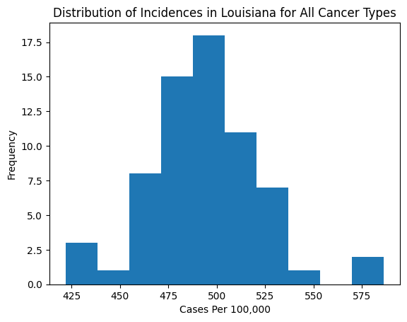

```python
# Histogram of Distribution of Incidences
TidyLAallcancer_df["Cases Per 100,000"].plot.hist()

# Labeling the Histogram
plt.xlabel("Cases Per 100,000")
plt.ylabel("Frequency")
plt.title("Distribution of Incidences in Louisiana for All Cancer Types")
```

We also locate the average annual count of cases for Louisiana as a whole.

```python
TidyLAallcancer_df.loc[0:1]
```

|  | Parish | FIPS | Cases Per 100,000 | Average Annual Count |
| --- | --- | --- | --- | --- |
| 0 | Louisiana(7) | 22000 | 483.6 | 26851 |
| 1 | US (SEER+NPCR)(1) | 0 | 444.4 | 1744459 |

**Data Discussion:** This graph is relevant because it shows us that Louisiana has a pretty symmetrical distribution of cancer incidences. However, this also shows us that Louisiana has a higher average per 100,000 cases for cancer incidences than the national average. We also know that Louisiana is the state with the most petrochemical plants. Once further exploration of more data is done, this graph could be beneficial in concluding correlation between number of petrochemical plants and number of cancer incidences.

Here, we create dataframes representing only the parishes that are in Cancer Alley and the LA counties that are not in Cancer Alley to visually compare the rate of incidences.

```python
# Cancer alley parishes left that did not have NaN values that were dropped
cancer_alley = ["Iberville Parish(7)", "West Baton Rouge Parish(7)", "East Baton Rouge Parish(7)", "Ascension Parish(7)", "St. James Parish(7)", "St. John the Baptist Parish(7)", "St. Charles Parish(7)", "Jefferson Parish(7)", "Orleans Parish(7)", "St. Bernard Parish(7)", "Plaquemines Parish(7)"]
# DataFrame for cancer alley only
cancer_alley_df = TidyLAallcancer_df[TidyLAallcancer_df['Parish'].isin(cancer_alley)].copy()
# DataFrame for the rest of LA excluding Cancer Alley parishes
restofLA_df = TidyLAallcancer_df[~TidyLAallcancer_df['Parish'].isin(cancer_alley)].copy()
```

We then use these dataframes to create histograms visualizing the distribution of cancer rates for all cancer types in Cancer Alley and in the rest of the parishes of Louisiana.

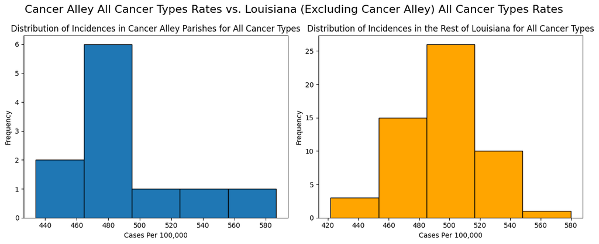

```python
plt.figure(figsize=(12, 5))
# Plotting Cancer Alley vs the rest of Louisiana cancer rates for all cancer types

plt.subplot(1, 2, 1)
plt.hist(cancer_alley_df['Cases Per 100,000'], bins=5, edgecolor='black')
plt.title('Distribution of Incidences in Cancer Alley Parishes for All Cancer Types')
plt.xlabel('Cases Per 100,000')
plt.ylabel('Frequency')

plt.subplot(1, 2, 2)
plt.hist(restofLA_df['Cases Per 100,000'], bins=5, edgecolor='black', color='orange')
plt.title('Distribution of Incidences in the Rest of Louisiana for All Cancer Types')
plt.xlabel('Cases Per 100,000')
plt.ylabel('Frequency')

plt.suptitle("Cancer Alley All Cancer Types Rates vs. Louisiana (Excluding Cancer Alley) All Cancer Types Rates", fontsize=16)
plt.tight_layout()
plt.show()
```

In addition to the histograms, we calculate descriptive statistics about the parishes that make up Cancer Alley and the rest of the parishes in Louisiana to compare them and see if there is a significant difference between the two.

```python
cancer_alley_df.describe()
```

|  | FIPS | Cases Per 100,000 | Average Annual Count |
| --- | --- | --- | --- |
| count | 11.000000 | 11.000000 | 11.000000 |
| mean | 22069.727273 | 490.727273 | 816.363636 |
| std | 33.036619 | 40.880780 | 984.669719 |
| min | 22005.000000 | 434.100000 | 122.000000 |
| 25% | 22049.000000 | 467.100000 | 187.500000 |
| 50% | 22075.000000 | 488.500000 | 228.000000 |
| 75% | 22091.000000 | 496.950000 | 1306.000000 |
| max | 22121.000000 | 586.400000 | 2623.000000 |

```python
restofLA_df.describe()
```

|  | FIPS | Cases Per 100,000 | Average Annual Count |
| --- | --- | --- | --- |
| count | 55.000000 | 55.000000 | 5.500000e+01 |
| mean | 21660.527273 | 495.152727 | 3.253064e+04 |
| std | 2975.040659 | 26.905740 | 2.351386e+05 |
| min | 0.000000 | 421.800000 | 3.200000e+01 |
| 25% | 22026.000000 | 480.450000 | 1.060000e+02 |
| 50% | 22059.000000 | 495.000000 | 1.930000e+02 |
| 75% | 22098.000000 | 509.850000 | 4.940000e+02 |
| max | 22127.000000 | 579.700000 | 1.744459e+06 |

Here, we create histograms visualizing the distribution of cancer incidences in Louisiana and in Vermont to later be compared to petrochemical plant density to analyze the differences between the two states.

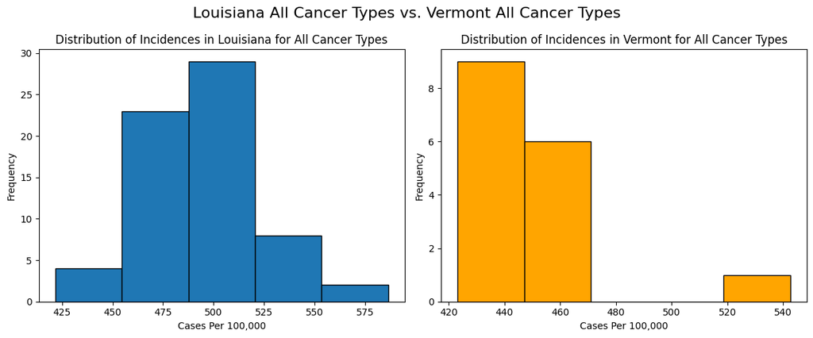

```python
plt.figure(figsize=(12, 5))
# Plotting Louisiana vs Vermont cancer rates for all cancer types

plt.subplot(1, 2, 1)
plt.hist(TidyLAallcancer_df['Cases Per 100,000'], bins=5, edgecolor='black')
plt.title('Distribution of Incidences in Louisiana for All Cancer Types')
plt.xlabel('Cases Per 100,000')
plt.ylabel('Frequency')

plt.subplot(1, 2, 2)
plt.hist(TidyVTallcancer_df['Cases Per 100,000'], bins=5, edgecolor='black', color='orange')
plt.title('Distribution of Incidences in Vermont for All Cancer Types')
plt.xlabel('Cases Per 100,000')
plt.ylabel('Frequency')


plt.suptitle("Louisiana All Cancer Types vs. Vermont All Cancer Types", fontsize=16)
plt.tight_layout()
plt.show()
```

We then calculated descriptive statistics for Louisiana and Vermont's cancer incidences to compare against the histograms to see if there were any revealing statistics unable to seen in the histograms.

```python
TidyLAallcancer_df.describe()
```

|  | FIPS | Cases Per 100,000 | Average Annual Count |
| --- | --- | --- | --- |
| count | 66.000000 | 66.000000 | 6.600000e+01 |
| mean | 21728.727273 | 494.415152 | 2.724492e+04 |
| std | 2716.028314 | 29.347657 | 2.146517e+05 |
| min | 0.000000 | 421.800000 | 3.200000e+01 |
| 25% | 22029.500000 | 477.750000 | 1.225000e+02 |
| 50% | 22062.000000 | 493.000000 | 2.115000e+02 |
| 75% | 22094.500000 | 509.050000 | 5.490000e+02 |
| max | 22127.000000 | 586.400000 | 1.744459e+06 |

```python
TidyVTallcancer_df.describe()
```

|  | FIPS | Cases Per 100,000 | Average Annual Count |
| --- | --- | --- | --- |
| count | 16.00000 | 16.000000 | 1.600000e+01 |
| mean | 46887.25000 | 450.112500 | 1.095316e+05 |
| std | 12503.26958 | 27.167404 | 4.359817e+05 |
| min | 0.00000 | 423.200000 | 4.600000e+01 |
| 25% | 50004.50000 | 438.100000 | 1.922500e+02 |
| 50% | 50012.00000 | 445.650000 | 2.700000e+02 |
| 75% | 50019.50000 | 450.000000 | 4.142500e+02 |
| max | 50027.00000 | 542.600000 | 1.744459e+06 |

**Data Discussion:** These graphs are relevant because they display the differences in cancer frequency in Louisiana, the state with the most petrochemical plants to frequency in Vermont, the state with the least petrochemical plants. Comparing these histograms, we can see that Louisiana has a much higher frequency of cancer. Louisiana's data is relatively normally distributed, whereas Vermont's data is slightly right skewed.

Here, we create two histograms to visualize the distributions of Leukemia rates in Louisiana and Vermont to see if there was any difference between number of Leukemia cases in Louisiana and Vermont and cases of all cancer types between the two states.

[figure not shown]

```python
plt.figure(figsize=(12, 5))
# Plotting Louisiana vs Vermont Leukemia Rates

plt.subplot(1, 2, 1)
plt.hist(TidyLAleukcancer_df['Cases Per 100,000'], bins=5, edgecolor='black')
plt.title('Distribution of Incidences in Louisiana for All Cancer Types')
plt.xlabel('Cases Per 100,000')
plt.ylabel('Frequency')
plt.setp(plt.gca().get_xticklabels(), rotation=90, ha='right')

plt.subplot(1, 2, 2)
plt.hist(TidyVTleukcancer_df['Cases Per 100,000'], bins=5, edgecolor='black', color='orange')
plt.title('Distribution of Incidences in Vermont for All Cancer Types')
plt.xlabel('Cases Per 100,000')
plt.ylabel('Frequency')
plt.setp(plt.gca().get_xticklabels(), rotation=90, ha='right')


plt.suptitle("Louisiana Leukemia Rates vs. Vermont Leukemia Rates", fontsize=16)
plt.tight_layout()
plt.show()
```

Then we calculated descriptive statistics about leukemia rates in Louisiana and Vermont to find anything significant that could not be seen in just the histograms alone.

```python
TidyLAleukcancer_df['Cases Per 100,000'] = pd.to_numeric(TidyLAleukcancer_df['Cases Per 100,000'], errors='coerce')
TidyLAleukcancer_df['Average Annual Count'] = pd.to_numeric(TidyLAleukcancer_df['Average Annual Count'], errors='coerce')
TidyLAleukcancer_df.describe()
```

|  | FIPS | Cases Per 100,000 | Average Annual Count |
| --- | --- | --- | --- |
| count | 50.000000 | 50.000000 | 50.000000 |
| mean | 21620.320000 | 15.248000 | 1090.720000 |
| std | 3120.199035 | 2.978922 | 7502.306837 |
| min | 0.000000 | 10.100000 | 3.000000 |
| 25% | 22028.000000 | 13.300000 | 5.000000 |
| 50% | 22062.000000 | 15.050000 | 8.500000 |
| 75% | 22094.500000 | 16.300000 | 20.500000 |
| max | 22121.000000 | 24.400000 | 53074.000000 |

```python
TidyVTleukcancer_df['Cases Per 100,000'] = pd.to_numeric(TidyVTleukcancer_df['Cases Per 100,000'], errors='coerce')
TidyVTleukcancer_df['Average Annual Count'] = pd.to_numeric(TidyVTleukcancer_df['Average Annual Count'], errors='coerce')
TidyVTleukcancer_df.describe()
```

|  | FIPS | Cases Per 100,000 | Average Annual Count |
| --- | --- | --- | --- |
| count | 14.000000 | 14.000000 | 14.000000 |
| mean | 46441.000000 | 13.785714 | 3807.214286 |
| std | 13366.642378 | 2.436535 | 14179.985376 |
| min | 0.000000 | 8.800000 | 4.000000 |
| 25% | 50003.500000 | 12.675000 | 7.000000 |
| 50% | 50013.000000 | 13.500000 | 8.500000 |
| 75% | 50020.500000 | 14.175000 | 11.500000 |
| max | 50027.000000 | 18.900000 | 53074.000000 |

Here, we create separate dataframes for leukemia rates in Cancer Alley and leukemia rates in the rest of Louisiana.

```python
# Cancer alley parishes left that did not have NaN values that were dropped
cancer_alley = ["Iberville Parish(7)", "West Baton Rouge Parish(7)", "East Baton Rouge Parish(7)", "Ascension Parish(7)", "St. James Parish(7)", "St. John the Baptist Parish(7)", "St. Charles Parish(7)", "Jefferson Parish(7)", "Orleans Parish(7)", "St. Bernard Parish(7)", "Plaquemines Parish(7)"]
# DataFrame for cancer alley only
leukcancer_alley_df = TidyLAleukcancer_df[TidyLAleukcancer_df['Parish'].isin(cancer_alley)].copy()
# DataFrame for the rest of LA excluding Cancer Alley parishes
leukrestofLA_df = TidyLAleukcancer_df[~TidyLAleukcancer_df['Parish'].isin(cancer_alley)].copy()
```

Then, using these dataframes, we create bar charts to visualize leukemia rates in Cancer Alley and the rest of Louisiana.

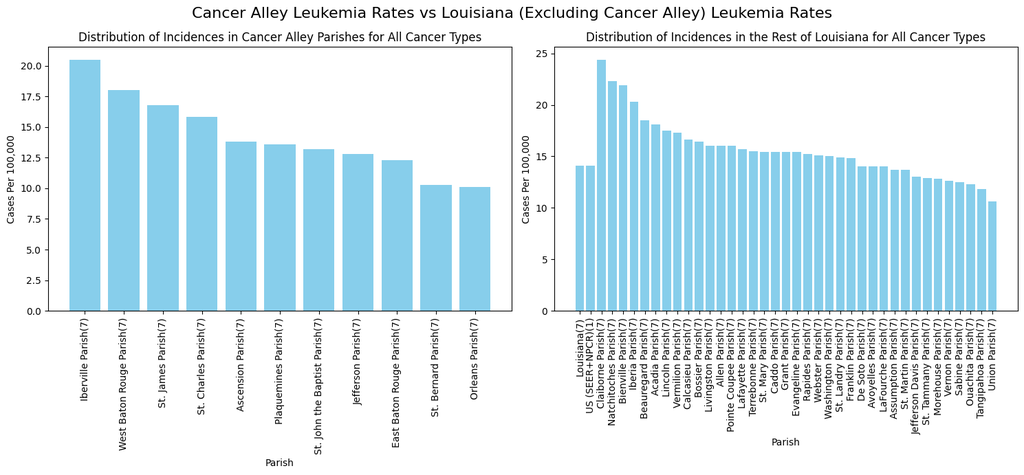

```python
fig, (ax1, ax2) = plt.subplots(nrows=1, ncols=2, figsize=(15, 7))

# Plotting Cancer Alley Bar Graph
ax1.bar(leukcancer_alley_df['Parish'], leukcancer_alley_df['Cases Per 100,000'], color='skyblue')
ax1.set_title('Distribution of Incidences in Cancer Alley Parishes for All Cancer Types')
ax1.set_xlabel('Parish')
ax1.set_ylabel('Cases Per 100,000')
ax1.tick_params(axis="x", rotation=90)

# Plotting rest of Louisiana Bar Graph
ax2.bar(leukrestofLA_df['Parish'], leukrestofLA_df['Cases Per 100,000'], color='skyblue')
ax2.set_title('Distribution of Incidences in the Rest of Louisiana for All Cancer Types')
ax2.set_xlabel('Parish')
ax2.set_ylabel('Cases Per 100,000')
ax2.tick_params(axis="x", rotation=90)
plt.suptitle("Cancer Alley Leukemia Rates vs Louisiana (Excluding Cancer Alley) Leukemia Rates", fontsize=16)
plt.tight_layout()
plt.show()
```

Using these dataframes, we also calculate descriptive statistics about leukemia rates in Cancer Alley and the rest of Louisiana.

```python
leukcancer_alley_df.describe()
```

|  | FIPS | Cases Per 100,000 | Average Annual Count |
| --- | --- | --- | --- |
| count | 11.000000 | 11.000000 | 11.000000 |
| mean | 22069.727273 | 14.290909 | 20.363636 |
| std | 33.036619 | 3.201079 | 23.871626 |
| min | 22005.000000 | 10.100000 | 3.000000 |
| 25% | 22049.000000 | 12.550000 | 5.500000 |
| 50% | 22075.000000 | 13.600000 | 7.000000 |
| 75% | 22091.000000 | 16.300000 | 29.000000 |
| max | 22121.000000 | 20.500000 | 68.000000 |

```python
leukrestofLA_df.describe()
```

|  | FIPS | Cases Per 100,000 | Average Annual Count |
| --- | --- | --- | --- |
| count | 39.000000 | 39.000000 | 39.000000 |
| mean | 21493.564103 | 15.517949 | 1392.615385 |
| std | 3532.508031 | 2.899353 | 8494.244654 |
| min | 0.000000 | 10.600000 | 3.000000 |
| 25% | 22018.000000 | 13.850000 | 5.000000 |
| 50% | 22057.000000 | 15.200000 | 9.000000 |
| 75% | 22098.000000 | 16.200000 | 20.000000 |
| max | 22119.000000 | 24.400000 | 53074.000000 |

**Data Discussion:** These graphs are relevant because they allow us to compare the frequency of leukemia in Cancer Alley to leukemia rates in the rest of Louisiana. We were surprised to see that the average number of cases per 100,000 people was lower for the Cancer Alley parishes than for the rest of Louisiana because this contradicts the rest of our findings. The standard deviation is slightly higher for the Cancer Alley parishes, but the median for the rest of Louisiana is higher than for Cancer Alley. Population size could be an influencing factor for this difference, but frequency is measured in cases per 100,000, so population size differences should already be accounted for. Further analysis will be needed to determine the cause of this difference.

Next, we create bar charts to visualize the CDC's SVI by Racial and Ethnic Minority Status for each county in Vermont and each parish in Louisiana.

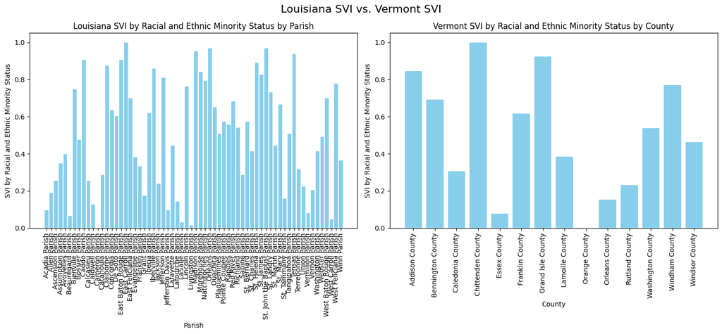

```python
fig, (ax1, ax2) = plt.subplots(nrows=1, ncols=2, figsize=(15, 7))

# Plotting Louisiana SVI
ax1.bar(TidyLA_SVI['Parish'], TidyLA_SVI['SVI by Racial and Ethnic Minority Status'], color='skyblue')
ax1.set_title('Louisiana SVI by Racial and Ethnic Minority Status by Parish')
ax1.set_xlabel('Parish')
ax1.set_ylabel('SVI by Racial and Ethnic Minority Status')
ax1.tick_params(axis="x", rotation=90)

# Plotting Vermont SVI
ax2.bar(TidyVT_SVI['County'], TidyVT_SVI['SVI by Racial and Ethnic Minority Status'], color='skyblue')
ax2.set_title('Vermont SVI by Racial and Ethnic Minority Status by County')
ax2.set_xlabel('County')
ax2.set_ylabel('SVI by Racial and Ethnic Minority Status')
ax2.tick_params(axis="x", rotation=90)

plt.suptitle("Louisiana SVI vs. Vermont SVI", fontsize=16)
plt.tight_layout()
plt.show()
```

To further explore this data, we also calculate descriptive statistics for each state based on this SVI data.

```python
TidyLA_SVI.describe()
```

|  | SVI by Racial and Ethnic Minority Status | FIPS |
| --- | --- | --- |
| count | 64.000000 | 64.000000 |
| mean | 0.497520 | 22064.000000 |
| std | 0.295344 | 37.237973 |
| min | 0.000000 | 22001.000000 |
| 25% | 0.250025 | 22032.500000 |
| 50% | 0.500000 | 22064.000000 |
| 75% | 0.749975 | 22095.500000 |
| max | 1.000000 | 22127.000000 |

```python
TidyVT_SVI.describe()
```

|  | SVI by Racial and Ethnic Minority Status | FIPS |
| --- | --- | --- |
| count | 14.000000 | 14.0000 |
| mean | 0.500000 | 50014.0000 |
| std | 0.321802 | 8.3666 |
| min | 0.000000 | 50001.0000 |
| 25% | 0.250025 | 50007.5000 |
| 50% | 0.500000 | 50014.0000 |
| 75% | 0.749975 | 50020.5000 |
| max | 1.000000 | 50027.0000 |

To further explore the SVI dataset, we create new dataframes for SVI in Cancer Alley and SVI in the rest of Louisiana.

```python
# Cancer alley parishes left that did not have NaN values that were dropped
cancer_alley = ["Iberville Parish", "West Baton Rouge Parish", "East Baton Rouge Parish", "Ascension Parish", "St. James Parish", "St. John the Baptist Parish", "St. Charles Parish", "Jefferson Parish", "Orleans Parish", "St. Bernard Parish", "Plaquemines Parish"]
# DataFrame for cancer alley only
svi_cancer_alley_df = TidyLA_SVI[TidyLA_SVI['Parish'].isin(cancer_alley)].copy()
# DataFrame for the rest of LA excluding Cancer Alley parishes
svi_restofLA_df = TidyLA_SVI[~TidyLA_SVI['Parish'].isin(cancer_alley)].copy()
```

Using these new dataframes, we create bar charts to visualize SVI by Racial and Ethnic Minority Status for parishes within Cancer Alley and parishes in the rest of Louisiana.

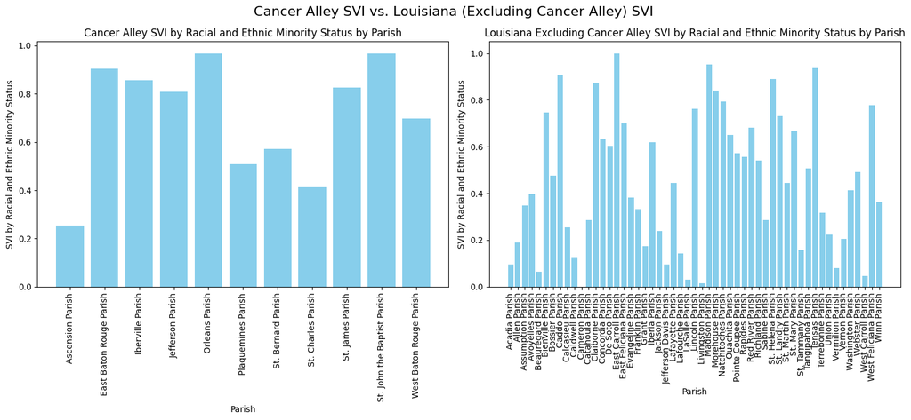

```python
fig, (ax1, ax2) = plt.subplots(nrows=1, ncols=2, figsize=(15, 7))

# Plotting Cancer Alley SVI
ax1.bar(svi_cancer_alley_df['Parish'], svi_cancer_alley_df['SVI by Racial and Ethnic Minority Status'], color='skyblue')
ax1.set_title('Cancer Alley SVI by Racial and Ethnic Minority Status by Parish')
ax1.set_xlabel('Parish')
ax1.set_ylabel('SVI by Racial and Ethnic Minority Status')
ax1.tick_params(axis="x", rotation=90)

# Plotting rest of Louisiana SVI
ax2.bar(svi_restofLA_df['Parish'], svi_restofLA_df['SVI by Racial and Ethnic Minority Status'], color='skyblue')
ax2.set_title('Louisiana Excluding Cancer Alley SVI by Racial and Ethnic Minority Status by Parish')
ax2.set_xlabel('Parish')
ax2.set_ylabel('SVI by Racial and Ethnic Minority Status')
ax2.tick_params(axis="x", rotation=90)

plt.suptitle("Cancer Alley SVI vs. Louisiana (Excluding Cancer Alley) SVI", fontsize=16)
plt.tight_layout()
plt.show()
```

We then use this dataset to calculate descriptive statistics for SVI in Cancer Alley and SVI in the rest of Louisiana.

```python
svi_cancer_alley_df.describe()
```

|  | SVI by Racial and Ethnic Minority Status | FIPS |
| --- | --- | --- |
| count | 11.000000 | 11.000000 |
| mean | 0.707073 | 22069.727273 |
| std | 0.239303 | 33.036619 |
| min | 0.254000 | 22005.000000 |
| 25% | 0.539650 | 22049.000000 |
| 50% | 0.809500 | 22075.000000 |
| 75% | 0.880950 | 22091.000000 |
| max | 0.968300 | 22121.000000 |

```python
svi_restofLA_df.describe()
```

|  | SVI by Racial and Ethnic Minority Status | FIPS |
| --- | --- | --- |
| count | 53.000000 | 53.000000 |
| mean | 0.454028 | 22062.811321 |
| std | 0.288878 | 38.232616 |
| min | 0.000000 | 22001.000000 |
| 25% | 0.206300 | 22029.000000 |
| 50% | 0.444400 | 22061.000000 |
| 75% | 0.682500 | 22099.000000 |
| max | 1.000000 | 22127.000000 |

**Data Discussion:** As these graphs show, parishes in Cancer Alley have some of the highest social vunerability indexes compared to the rest of Louisiana. This is due to petrochemical plants being sited near minority populations as well as petrochemical plants not abiding by EPA federal laws. This makes the populations in these parishes more susceptible to risks associated with petrochemical plants, such as cancer.

To explore the data on petrochemical plants, we create new dataframes representing petrochemical plants in Cancer Alley and in the rest of Louisiana.

```python
# Cancer alley parishes left that did not have NaN values that were dropped
cancer_alley = ["IBERVILLE PARISH, LA", "WEST BATON ROUGE PARISH, LA", "EAST BATON ROUGE PARISH, LA", "ASCENSION PARISH, LA", "ST. JAMES PARISH, LA", "ST. JOHN THE BAPTIST PARISH, LA", "ST. CHARLES PARISH, LA", "JEFFERSON PARISH, LA", "ORLEANS PARISH, LA", "ST. BERNARD PARISH, LA", "PLAQUEMINES PARISH, LA"]
# DataFrame for cancer alley only
petro_cancer_alley_df = tidy_la_petro[tidy_la_petro["Parish"].isin(cancer_alley)].copy()
# DataFrame for the rest of LA excluding Cancer Alley parishes
petro_restofLA_df = tidy_la_petro[~tidy_la_petro["Parish"].isin(cancer_alley)].copy()
```

We then create bar charts utilizing these new dataframes visualizing the frequency of petrochemical plants in Cancer Alley and in the rest of Louisiana.

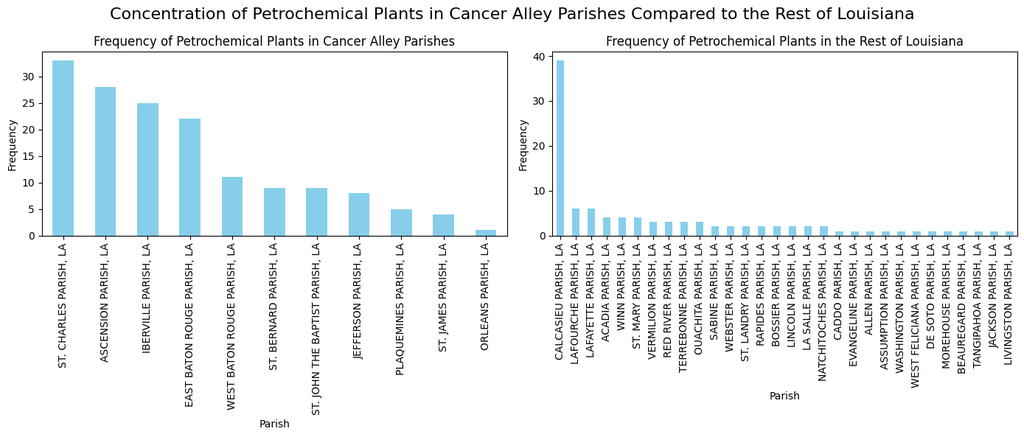

```python
fig, (ax1, ax2) = plt.subplots(nrows=1, ncols=2, figsize=(14, 6))

petro_cancer_alley_df['Parish'].value_counts().plot(kind='bar', ax=ax1, color="skyblue")

# Plotting plant frequency in cancer alley
ax1.set_title('Frequency of Petrochemical Plants in Cancer Alley Parishes')
ax1.set_xlabel('Parish')
ax1.set_ylabel('Frequency')
ax1.tick_params(axis="x", rotation=90)

petro_restofLA_df['Parish'].value_counts().plot(kind='bar', ax=ax2, color="skyblue")

# Plotting the plant frequency in the rest of louisiana
ax2.set_title("Frequency of Petrochemical Plants in the Rest of Louisiana")
ax2.set_xlabel('Parish')
ax2.set_ylabel('Frequency')
ax2.tick_params(axis="x", rotation=90)

plt.suptitle("Concentration of Petrochemical Plants in Cancer Alley Parishes Compared to the Rest of Louisiana", fontsize=16)
plt.tight_layout()
plt.show()
```

We then calculate descriptive statistics for Cancer Alley and the rest of Louisiana using the new dataframes.

```python
petro_cancer_alley_df.describe()
```

|  | Parish | State | Chemical | FIPS |
| --- | --- | --- | --- | --- |
| count | 155 | 155 | 155 | 155 |
| unique | 11 | 1 | 4 | 11 |
| top | ST. CHARLES PARISH, LA | Louisiana | methanol | 22089 |
| freq | 33 | 155 | 52 | 33 |

```python
petro_restofLA_df.describe()
```

|  | Parish | State | Chemical | FIPS |
| --- | --- | --- | --- | --- |
| count | 103 | 103 | 103 | 103 |
| unique | 30 | 1 | 4 | 30 |
| top | CALCASIEU PARISH, LA | Louisiana | methanol | 22019 |
| freq | 39 | 103 | 49 | 39 |

**Data Discussion:** These two graphs show us the density of petrochemical plants in Cancer Alley's 11 parishes compared to the petrochemical plant density in 30 other parishes. We see that majority of the Cancer Alley parishes have at least 5 plants, but it is hard to see how many petrochemical plants are in Cancer Alley vs the rest od Louisiana. So, when we use describe on both the DataFrames, we see that in the 11 parishes of Cancer Alley alone, there are 155 petrochemical plants. In the 30 other parishes that contain petrochemical plants, there are 103 plants. These statistics (shown below) that there is a disproportionate amount of petrochemical plants in the Cancer Alley region compared to the rest of Louisiana's parishes that contain plants.

# **Modeling**

Model Question: Is there a statistically significant relationship between SVI, number of petrochemical plants, and cancer incidence rates within a given parish?

First we are creating a dataframe called "Louisiana Parish Data." This dataframe will contain parish names, cancer rates, SVI data, and petrochemical plant data for each county we will use this dataframe to create a linear regression model.

Since each dataset names parishes differently, we merged the datasets based on their FIPS codes, or the numerical name for each parish.

```python
#First, we are adding population data to our dataframe
# Reading CSV file
LA_pop_df = pd.read_csv('/content/drive/MyDrive/DataScienceProject/LApopulation.csv', sep=',')
LA_pop_df.rename(columns = {"2024 population" : "2024 Population"},inplace=True)
```

```python
# First, we merge the three datasets together on their FIPS codes.
merged_df = pd.merge(TidyLA_SVI, TidyLAallcancer_df, on="FIPS")
merged_df_2 = pd.merge(merged_df, tidy_la_petro, on="FIPS")

# Dropping duplicate parish name columns and renaming kept column
merged_df_2.drop("Parish_y", axis=1, inplace=True)
merged_df_2.drop("Parish", axis=1, inplace=True)
merged_df_2.rename(columns = {"Parish_x":"County/Parish"},inplace=True)

# Add a column for number of chemical plants based on counts of chemicals per parish

# merged_df_2["Petrochemical plants"] = merged_df_2["Parish"].value_counts()

# merged_df_2

merged_df_2['Petrochemical plants'] = merged_df_2.groupby('County/Parish')['County/Parish'].transform('count')

# Now we can drop the chemical column and drop duplicate rows to tidy our data

merged_df_2.drop("Chemical", axis = 1, inplace=True)
no_duplicates_df = merged_df_2.drop_duplicates()
no_duplicates_df

# Dependent variable = cancer
# Independent variables = SVI and number of petrochemical plants
# Idea: plot cancer v.s. petrochemicals and change dot size based on SVI?

# Linear regression and do kruskal wallis?
```

|  | County/Parish | SVI by Racial and Ethnic Minority Status | FIPS | Cases Per 100,000 | Average Annual Count | State | Petrochemical plants |
| --- | --- | --- | --- | --- | --- | --- | --- |
| 0 | Acadia Parish | 0.0952 | 22001 | 532.2 | 370 | Louisiana | 4 |
| 4 | Allen Parish | 0.1905 | 22003 | 516.6 | 138 | Louisiana | 1 |
| 5 | Ascension Parish | 0.2540 | 22005 | 499.6 | 637 | Louisiana | 28 |
| 33 | Assumption Parish | 0.3492 | 22007 | 504.3 | 145 | Louisiana | 1 |
| 34 | Beauregard Parish | 0.0635 | 22011 | 520.2 | 223 | Louisiana | 1 |
| 35 | Bossier Parish | 0.4762 | 22015 | 477.2 | 683 | Louisiana | 2 |
| 37 | Caddo Parish | 0.9048 | 22017 | 481.8 | 1472 | Louisiana | 1 |
| 38 | Calcasieu Parish | 0.2540 | 22019 | 469.9 | 1154 | Louisiana | 39 |
| 77 | De Soto Parish | 0.6032 | 22031 | 508.6 | 179 | Louisiana | 1 |
| 78 | East Baton Rouge Parish | 0.9048 | 22033 | 475.3 | 2354 | Louisiana | 22 |
| 100 | Evangeline Parish | 0.3810 | 22039 | 510.6 | 200 | Louisiana | 1 |
| 101 | Iberville Parish | 0.8571 | 22047 | 586.4 | 228 | Louisiana | 25 |
| 126 | Jackson Parish | 0.2381 | 22049 | 509.1 | 107 | Louisiana | 1 |
| 127 | Jefferson Parish | 0.8095 | 22051 | 465.7 | 2623 | Louisiana | 8 |
| 135 | Lafayette Parish | 0.4444 | 22055 | 483.8 | 1273 | Louisiana | 6 |
| 141 | Lafourche Parish | 0.1429 | 22057 | 464.4 | 551 | Louisiana | 6 |
| 147 | LaSalle Parish | 0.0317 | 22059 | 495.0 | 88 | Louisiana | 2 |
| 149 | Lincoln Parish | 0.7619 | 22061 | 421.8 | 201 | Louisiana | 2 |
| 151 | Livingston Parish | 0.0159 | 22063 | 491.2 | 751 | Louisiana | 1 |
| 152 | Morehouse Parish | 0.8413 | 22067 | 492.1 | 171 | Louisiana | 1 |
| 153 | Natchitoches Parish | 0.7937 | 22069 | 520.7 | 230 | Louisiana | 2 |
| 155 | Orleans Parish | 0.9683 | 22071 | 434.1 | 1975 | Louisiana | 1 |
| 156 | Ouachita Parish | 0.6508 | 22073 | 481.3 | 880 | Louisiana | 3 |
| 159 | Plaquemines Parish | 0.5079 | 22075 | 468.5 | 122 | Louisiana | 5 |
| 164 | Rapides Parish | 0.5556 | 22079 | 479.6 | 761 | Louisiana | 2 |
| 166 | Red River Parish | 0.6825 | 22081 | 475.5 | 51 | Louisiana | 3 |
| 169 | Sabine Parish | 0.2857 | 22085 | 491.9 | 154 | Louisiana | 2 |
| 171 | St. Bernard Parish | 0.5714 | 22087 | 493.9 | 222 | Louisiana | 9 |
| 180 | St. Charles Parish | 0.4127 | 22089 | 488.5 | 295 | Louisiana | 33 |
| 213 | St. James Parish | 0.8254 | 22093 | 533.5 | 144 | Louisiana | 4 |
| 217 | St. John the Baptist Parish | 0.9683 | 22095 | 458.2 | 227 | Louisiana | 9 |
| 226 | St. Landry Parish | 0.7302 | 22097 | 542.3 | 543 | Louisiana | 2 |

```python
#Adding in the population data
LA_pop_df


merged_LA = pd.merge(no_duplicates_df, LA_pop_df, on="FIPS")
merged_LA.drop("Parish",axis=1,inplace=True)
merged_LA
```

|  | County/Parish | SVI by Racial and Ethnic Minority Status | FIPS | Cases Per 100,000 | Average Annual Count | State | Petrochemical plants | 2024 Population |
| --- | --- | --- | --- | --- | --- | --- | --- | --- |
| 0 | Acadia Parish | 0.0952 | 22001 | 532.2 | 370 | Louisiana | 4 | 56604 |
| 1 | Allen Parish | 0.1905 | 22003 | 516.6 | 138 | Louisiana | 1 | 22501 |
| 2 | Ascension Parish | 0.2540 | 22005 | 499.6 | 637 | Louisiana | 28 | 133534 |
| 3 | Assumption Parish | 0.3492 | 22007 | 504.3 | 145 | Louisiana | 1 | 20050 |
| 4 | Beauregard Parish | 0.0635 | 22011 | 520.2 | 223 | Louisiana | 1 | 36695 |
| 5 | Bossier Parish | 0.4762 | 22015 | 477.2 | 683 | Louisiana | 2 | 131102 |
| 6 | Caddo Parish | 0.9048 | 22017 | 481.8 | 1472 | Louisiana | 1 | 224893 |
| 7 | Calcasieu Parish | 0.2540 | 22019 | 469.9 | 1154 | Louisiana | 39 | 206861 |
| 8 | De Soto Parish | 0.6032 | 22031 | 508.6 | 179 | Louisiana | 1 | 27274 |
| 9 | East Baton Rouge Parish | 0.9048 | 22033 | 475.3 | 2354 | Louisiana | 22 | 453022 |
| 10 | Evangeline Parish | 0.3810 | 22039 | 510.6 | 200 | Louisiana | 1 | 31745 |
| 11 | Iberville Parish | 0.8571 | 22047 | 586.4 | 228 | Louisiana | 25 | 29766 |
| 12 | Jackson Parish | 0.2381 | 22049 | 509.1 | 107 | Louisiana | 1 | 14797 |
| 13 | Jefferson Parish | 0.8095 | 22051 | 465.7 | 2623 | Louisiana | 8 | 427253 |
| 14 | Lafayette Parish | 0.4444 | 22055 | 483.8 | 1273 | Louisiana | 6 | 254241 |
| 15 | Lafourche Parish | 0.1429 | 22057 | 464.4 | 551 | Louisiana | 6 | 95342 |
| 16 | LaSalle Parish | 0.0317 | 22059 | 495.0 | 88 | Louisiana | 2 | 14702 |
| 17 | Lincoln Parish | 0.7619 | 22061 | 421.8 | 201 | Louisiana | 2 | 48243 |
| 18 | Livingston Parish | 0.0159 | 22063 | 491.2 | 751 | Louisiana | 1 | 152886 |
| 19 | Morehouse Parish | 0.8413 | 22067 | 492.1 | 171 | Louisiana | 1 | 23787 |
| 20 | Natchitoches Parish | 0.7937 | 22069 | 520.7 | 230 | Louisiana | 2 | 35982 |
| 21 | Orleans Parish | 0.9683 | 22071 | 434.1 | 1975 | Louisiana | 1 | 362701 |
| 22 | Ouachita Parish | 0.6508 | 22073 | 481.3 | 880 | Louisiana | 3 | 157874 |
| 23 | Plaquemines Parish | 0.5079 | 22075 | 468.5 | 122 | Louisiana | 5 | 22289 |
| 24 | Rapides Parish | 0.5556 | 22079 | 479.6 | 761 | Louisiana | 2 | 125899 |
| 25 | Red River Parish | 0.6825 | 22081 | 475.5 | 51 | Louisiana | 3 | 7238 |
| 26 | Sabine Parish | 0.2857 | 22085 | 491.9 | 154 | Louisiana | 2 | 21746 |
| 27 | St. Bernard Parish | 0.5714 | 22087 | 493.9 | 222 | Louisiana | 9 | 44783 |
| 28 | St. Charles Parish | 0.4127 | 22089 | 488.5 | 295 | Louisiana | 33 | 50400 |
| 29 | St. James Parish | 0.8254 | 22093 | 533.5 | 144 | Louisiana | 4 | 19110 |
| 30 | St. John the Baptist Parish | 0.9683 | 22095 | 458.2 | 227 | Louisiana | 9 | 39694 |
| 31 | St. Landry Parish | 0.7302 | 22097 | 542.3 | 543 | Louisiana | 2 | 80869 |

Next, we are creating a similar dataframe for our Vermont data to be able to use in our model to compare to Louisiana

```python
#Loading in VT pop data
# Reading CSV file
VT_pop_df = pd.read_csv('/content/drive/MyDrive/DataScienceProject/VTpopulation.csv', sep=',')
VT_pop_df
```

|  | County | FIPS | 2024 Population |
| --- | --- | --- | --- |
| 0 | .Addison County, Vermont | 50001 | 38047 |
| 1 | .Bennington County, Vermont | 50003 | 37039 |
| 2 | .Caledonia County, Vermont | 50005 | 30535 |
| 3 | .Chittenden County, Vermont | 50007 | 170851 |
| 4 | .Essex County, Vermont | 50009 | 6037 |
| 5 | .Franklin County, Vermont | 50011 | 51066 |
| 6 | .Grand Isle County, Vermont | 50013 | 7528 |
| 7 | .Lamoille County, Vermont | 50015 | 26248 |
| 8 | .Orange County, Vermont | 50017 | 30050 |
| 9 | .Orleans County, Vermont | 50019 | 27726 |
| 10 | .Rutland County, Vermont | 50021 | 60198 |
| 11 | .Washington County, Vermont | 50023 | 59844 |
| 12 | .Windham County, Vermont | 50025 | 45627 |
| 13 | .Windsor County, Vermont | 50027 | 57697 |

```python
merged_VT_without_pop = pd.merge(TidyVT_SVI,TidyVTallcancer_df,on="FIPS")
merged_VT = pd.merge(merged_VT_without_pop,VT_pop_df,on="FIPS")
merged_VT.drop("County",axis=1,inplace=True)
# Drop duplicate county column and rename county column

merged_VT.drop("County_y", axis=1, inplace=True)
merged_VT.rename(columns = {"County_x":"County/Parish"},inplace=True)
merged_VT["Petrochemical plants"] = 0
merged_VT["State"] = "Vermont"
merged_VT
```

|  | County/Parish | SVI by Racial and Ethnic Minority Status | FIPS | Cases Per 100,000 | Average Annual Count | 2024 Population | Petrochemical plants | State |
| --- | --- | --- | --- | --- | --- | --- | --- | --- |
| 0 | Addison County | 0.8462 | 50001 | 423.2 | 226 | 38047 | 0 | Vermont |
| 1 | Bennington County | 0.6923 | 50003 | 445.9 | 262 | 37039 | 0 | Vermont |
| 2 | Caledonia County | 0.3077 | 50005 | 453.6 | 199 | 30535 | 0 | Vermont |
| 3 | Chittenden County | 1.0000 | 50007 | 448.8 | 875 | 170851 | 0 | Vermont |
| 4 | Essex County | 0.0769 | 50009 | 425.9 | 46 | 6037 | 0 | Vermont |
| 5 | Franklin County | 0.6154 | 50011 | 445.4 | 278 | 51066 | 0 | Vermont |
| 6 | Grand Isle County | 0.9231 | 50013 | 542.6 | 60 | 7528 | 0 | Vermont |
| 7 | Lamoille County | 0.3846 | 50015 | 435.7 | 150 | 26248 | 0 | Vermont |
| 8 | Orange County | 0.0000 | 50017 | 433.2 | 194 | 30050 | 0 | Vermont |
| 9 | Orleans County | 0.1538 | 50019 | 457.0 | 187 | 27726 | 0 | Vermont |
| 10 | Rutland County | 0.2308 | 50021 | 469.6 | 451 | 60198 | 0 | Vermont |
| 11 | Washington County | 0.5385 | 50023 | 448.0 | 381 | 59844 | 0 | Vermont |
| 12 | Windham County | 0.7692 | 50025 | 438.9 | 311 | 45627 | 0 | Vermont |
| 13 | Windsor County | 0.4615 | 50027 | 442.3 | 402 | 57697 | 0 | Vermont |

Now we will bring the Louisiana and Vermont data together so we can make a negative binomial regression model.

```python
combined_all_data = pd.concat([merged_VT,merged_LA])
combined_all_data.rename(columns = {"Average Annual Count":"Average_Annual_Count", "2024 Population": "Population", "SVI by Racial and Ethnic Minority Status": "SVI", "Petrochemical plants": "Petrochemical_Plants"} ,inplace=True)
# Convert all required columns to numeric
combined_all_data['Average_Annual_Count'] = pd.to_numeric(
    combined_all_data['Average_Annual_Count'],
    errors='coerce'
)
combined_all_data['Petrochemical_Plants'] = pd.to_numeric(
    combined_all_data['Petrochemical_Plants'],
    errors='coerce'
)
combined_all_data['SVI'] = pd.to_numeric(
    combined_all_data['SVI'],
    errors='coerce'
)
combined_all_data['Population'] = pd.to_numeric(
    combined_all_data['Population'],
    errors='coerce'
)
combined_all_data
```

|  | County/Parish | SVI | FIPS | Cases Per 100,000 | Average_Annual_Count | Population | Petrochemical_Plants | State |
| --- | --- | --- | --- | --- | --- | --- | --- | --- |
| 0 | Addison County | 0.8462 | 50001 | 423.2 | 226 | 38047 | 0 | Vermont |
| 1 | Bennington County | 0.6923 | 50003 | 445.9 | 262 | 37039 | 0 | Vermont |
| 2 | Caledonia County | 0.3077 | 50005 | 453.6 | 199 | 30535 | 0 | Vermont |
| 3 | Chittenden County | 1.0000 | 50007 | 448.8 | 875 | 170851 | 0 | Vermont |
| 4 | Essex County | 0.0769 | 50009 | 425.9 | 46 | 6037 | 0 | Vermont |
| 5 | Franklin County | 0.6154 | 50011 | 445.4 | 278 | 51066 | 0 | Vermont |
| 6 | Grand Isle County | 0.9231 | 50013 | 542.6 | 60 | 7528 | 0 | Vermont |
| 7 | Lamoille County | 0.3846 | 50015 | 435.7 | 150 | 26248 | 0 | Vermont |
| 8 | Orange County | 0.0000 | 50017 | 433.2 | 194 | 30050 | 0 | Vermont |
| 9 | Orleans County | 0.1538 | 50019 | 457.0 | 187 | 27726 | 0 | Vermont |
| 10 | Rutland County | 0.2308 | 50021 | 469.6 | 451 | 60198 | 0 | Vermont |
| 11 | Washington County | 0.5385 | 50023 | 448.0 | 381 | 59844 | 0 | Vermont |
| 12 | Windham County | 0.7692 | 50025 | 438.9 | 311 | 45627 | 0 | Vermont |
| 13 | Windsor County | 0.4615 | 50027 | 442.3 | 402 | 57697 | 0 | Vermont |
| 0 | Acadia Parish | 0.0952 | 22001 | 532.2 | 370 | 56604 | 4 | Louisiana |
| 1 | Allen Parish | 0.1905 | 22003 | 516.6 | 138 | 22501 | 1 | Louisiana |
| 2 | Ascension Parish | 0.2540 | 22005 | 499.6 | 637 | 133534 | 28 | Louisiana |
| 3 | Assumption Parish | 0.3492 | 22007 | 504.3 | 145 | 20050 | 1 | Louisiana |
| 4 | Beauregard Parish | 0.0635 | 22011 | 520.2 | 223 | 36695 | 1 | Louisiana |
| 5 | Bossier Parish | 0.4762 | 22015 | 477.2 | 683 | 131102 | 2 | Louisiana |
| 6 | Caddo Parish | 0.9048 | 22017 | 481.8 | 1472 | 224893 | 1 | Louisiana |
| 7 | Calcasieu Parish | 0.2540 | 22019 | 469.9 | 1154 | 206861 | 39 | Louisiana |
| 8 | De Soto Parish | 0.6032 | 22031 | 508.6 | 179 | 27274 | 1 | Louisiana |
| 9 | East Baton Rouge Parish | 0.9048 | 22033 | 475.3 | 2354 | 453022 | 22 | Louisiana |
| 10 | Evangeline Parish | 0.3810 | 22039 | 510.6 | 200 | 31745 | 1 | Louisiana |
| 11 | Iberville Parish | 0.8571 | 22047 | 586.4 | 228 | 29766 | 25 | Louisiana |
| 12 | Jackson Parish | 0.2381 | 22049 | 509.1 | 107 | 14797 | 1 | Louisiana |
| 13 | Jefferson Parish | 0.8095 | 22051 | 465.7 | 2623 | 427253 | 8 | Louisiana |
| 14 | Lafayette Parish | 0.4444 | 22055 | 483.8 | 1273 | 254241 | 6 | Louisiana |
| 15 | Lafourche Parish | 0.1429 | 22057 | 464.4 | 551 | 95342 | 6 | Louisiana |
| 16 | LaSalle Parish | 0.0317 | 22059 | 495.0 | 88 | 14702 | 2 | Louisiana |
| 17 | Lincoln Parish | 0.7619 | 22061 | 421.8 | 201 | 48243 | 2 | Louisiana |
| 18 | Livingston Parish | 0.0159 | 22063 | 491.2 | 751 | 152886 | 1 | Louisiana |
| 19 | Morehouse Parish | 0.8413 | 22067 | 492.1 | 171 | 23787 | 1 | Louisiana |
| 20 | Natchitoches Parish | 0.7937 | 22069 | 520.7 | 230 | 35982 | 2 | Louisiana |
| 21 | Orleans Parish | 0.9683 | 22071 | 434.1 | 1975 | 362701 | 1 | Louisiana |
| 22 | Ouachita Parish | 0.6508 | 22073 | 481.3 | 880 | 157874 | 3 | Louisiana |
| 23 | Plaquemines Parish | 0.5079 | 22075 | 468.5 | 122 | 22289 | 5 | Louisiana |
| 24 | Rapides Parish | 0.5556 | 22079 | 479.6 | 761 | 125899 | 2 | Louisiana |
| 25 | Red River Parish | 0.6825 | 22081 | 475.5 | 51 | 7238 | 3 | Louisiana |
| 26 | Sabine Parish | 0.2857 | 22085 | 491.9 | 154 | 21746 | 2 | Louisiana |
| 27 | St. Bernard Parish | 0.5714 | 22087 | 493.9 | 222 | 44783 | 9 | Louisiana |
| 28 | St. Charles Parish | 0.4127 | 22089 | 488.5 | 295 | 50400 | 33 | Louisiana |
| 29 | St. James Parish | 0.8254 | 22093 | 533.5 | 144 | 19110 | 4 | Louisiana |
| 30 | St. John the Baptist Parish | 0.9683 | 22095 | 458.2 | 227 | 39694 | 9 | Louisiana |
| 31 | St. Landry Parish | 0.7302 | 22097 | 542.3 | 543 | 80869 | 2 | Louisiana |

```python
import statsmodels.api as sm
import statsmodels.formula.api as smf
import warnings
warnings.filterwarnings("ignore")

# Define the formula: log(Expected_Cases) = Intercept + beta1*Plant_Density + beta2*SVI + log(Population)
# 'offset=np.log(df["Population"])' transforms the model to estimate a rate
model_formula = 'Average_Annual_Count ~ Petrochemical_Plants + SVI'

# Create and fit the Negative Binomial model
negbin_model = smf.glm(
    formula=model_formula,
    data=combined_all_data,
    family=sm.families.NegativeBinomial(link=sm.genmod.families.links.log()),
    exposure=combined_all_data['Population']
).fit()

# Print the summary to check for statistical significance
print("Negative Binomial Regression Results\n")
print(negbin_model.summary())
```

```
Negative Binomial Regression Results

                  Generalized Linear Model Regression Results
================================================================================
Dep. Variable:     Average_Annual_Count   No. Observations:                   46
Model:                              GLM   Df Residuals:                       43
Model Family:          NegativeBinomial   Df Model:                            2
Link Function:                      log   Scale:                          1.0000
Method:                            IRLS   Log-Likelihood:                -310.24
Date:                  Thu, 11 Dec 2025   Deviance:                      0.88441
Time:                          06:03:38   Pearson chi2:                    0.861
No. Iterations:                       5   Pseudo R-squ. (CS):           0.001251
Covariance Type:              nonrobust
========================================================================================
                           coef    std err          z      P>|z|      [0.025      0.975]
----------------------------------------------------------------------------------------
Intercept               -5.0616      0.303    -16.708      0.000      -5.655      -4.468
Petrochemical_Plants    -0.0039      0.016     -0.241      0.810      -0.036       0.028
SVI                      0.0012      0.492      0.002      0.998      -0.964       0.966
========================================================================================
```